# Script9_Armbruster2026_HindbrainSubset

Daniel Armbruster

2026-07-24

- In this script we subset the hindbrain cluster Hb1, Hb2 and Hb3 from the whole dataset presented in Figure 1C and performed a standard clustering workflow on them followed by annotation. The data of the differentially expressed gene analysis is shown in Table S3D and is the basis for the generation of the heatmap depicting the scaled expression of transcription factors with the highest fold change per cluster compared to the other clusters that is shown in Figure 3D and the corresponding numerical data in Table S3C+D.
- In Section 8.3 and 8.4 we calculated a score as approximation for the position of hindbrain cells based on their hox gene expression which we termed rostro-caudal identity score (hox RC score). See Section 8.3 and 8.4 for more detailed explanation. The visualization of the hox RC score depicted in a UMAP plot as well as the expression of individual hox gene visualized as DotPlot are depicted in Figure S3 C+D.
- In addition, this script generated the plots presented in Figure 3A+B and Figure S3A.
- The session info including the used packages and their versions is provided at the end of this script.

# 1. Load Packages

```r
library(Seurat)
library(dplyr)
library(openxlsx)
library(tidyverse)
library(cowplot)
library(tidyverse)
```

# 2. Load Data

```r
normalized_cells_clustered <- readRDS(file = "RDS_files/Script3_Armbruster2026_annotated.rds")
```

# 3. Subsetting of hindbrain NA neurons

```r
HB_normalized_cells <- subset(normalized_cells_clustered, idents = c("Hb1", "Hb2", "Hb3"))
```

# 4. Standard workflow and clustering

```r
DefaultAssay(HB_normalized_cells) <- "RNA"
HB_normalized_cells <- FindVariableFeatures(HB_normalized_cells, selection.method = "vst", nfeatures = 2000, verbose = FALSE)
HB_normalized_cells <- ScaleData(HB_normalized_cells)
HB_normalized_cells <- RunPCA(HB_normalized_cells)
```

```
## PC_ 1
## Positive:  zfhx4, zfhx3, nrp1a, adcyap1b, cbln1, CABZ01072077.1, clstn2, atp1a1b, gpc1a, casz1
##     tac3a, spon1a, hoxb6b, tlx2, mdkb, pth1ra, chrnb2l, si:ch73-386h18.1, pyya, msi1
##     calb2a, tmem235, oprl1, efnb2a, tspan7, cdh13, chrnb3b, ret, pou4f1, im:7142702
## Negative:  nr4a3, slc6a2, pcdh17, tfap2b, frmpd3, hpca, mao, rgs4, slc35g2a, elavl4
##     msi2a, slc31a1, si:dkey-180p18.9, ngfra, cdh6, rasgrf2b, dab1a, syt10, ncam2, tfap2a
##     junbb, fam19a5a, egr4, gadd45ba, sall3a, sall1a, dbh, pvalb6, znf503, pbx1a
## PC_ 2
## Positive:  foxo1a, mcama, dbh, lmo3, agrn, ddc, slc31a1, sulf2b, nfasca, epas1b
##     gch1, mef2cb, hoxb6a, ttyh2l, pappaa, hoxb6b, zgc:158343, prkg2, tshz3b, scg2b
##     cish, gfra3, stk10, alcama, syt6b, necab1, CABZ01072077.1, tshz1, hoxb5a, rbp5
## Negative:  robo2.1, meis1b, meis2b, kif26ba, pyya, meis2a, slc1a2b, pou4f1, cart2, im:7142702
##     tac3a, nmu, mab21l2, islr2, tmem235, pcp4a, rbfox1, mab21l1, grm8a, sulf2a
##     sstr2a, syt9a, cplx1, nptx1l, lrp1bb, ptprua, pcdh19, nrp1a, c1qtnf4, uncx
## PC_ 3
## Positive:  necab2, pvalb6, rbfox1, rpz5, pou4f1, unc5da, fabp3, syt9b, tmsb2, kctd12.1
##     FP085414.1, ralyl, vsnl1b, slc7a14a, pbx1a, meis2a, si:dkey-56f14.4, nptx1l, igdcc3, rprmb
##     cbln2b, zgc:91860, tubb2b, sall3b, nmu, olfm1b, sall1a, snap25a, rbfox3a, luzp2
## Negative:  CABZ01056321.1, ppp1r18, fam46ab, cplx4a, elovl4b, si:dkeyp-57d7.4, rp1l1b, rx1, slc24a2, grk7a
##     si:ch211-160o17.6, rcvrn2, cacna2d4b, ankrd33ba, atp2b1b, gabra6a, opn1sw1, eno1b, si:rp71-39b20.4, si:ch211-221f10.2
##     prph2a, scamp5b, grk1b, prph2b, nexn, ppp1r13ba, CABZ01074816.1, rcvrna, ogdhl, gc3
## PC_ 4
## Positive:  mdkb, spon1a, pcp4a, pou4f1, pyya, mab21l2, grm8a, tmem235, nmu, vav3b
##     sstr2a, islr2, im:7142702, khdrbs2, rxraa, epha4b, robo2.1, chrm2a, cpne2, rbfox1
##     roraa, clstn2, olfm1b, rgs16, mef2cb, syt9a, foxo1a, khdrbs1b, cdh13, CU302436.3
## Negative:  crhbp, cbln1, atp1a1b, msi1, mlnr, nhlh2, chrnb3b, cart4, CR786577.1, mmel1
##     tspan7, ntng1a, chrnb2l, casz1, egfra, ENSDARG00000097208, pth1ra, gpc1a, grin2ca, dtnbp1b
##     si:dkey-1h6.8, CABZ01072077.1, nedd9, bcam, tmtopsb, hdac9b, vim, TENM3, ttyh2l, itga6a
## PC_ 5
## Positive:  sall1a, chgb, th, rpz5, unc5da, nmu, hoxb5b, tac3a, sstr2a, FP085414.1
##     tmem235, plcb3, hoxc5a, pou4f1, slc7a14a, slc6a1b, im:7142702, pyya, gfra1b, calb2b
##     hoxb5a, islr2, zgc:158343, pbx1a, bdnf, ucp3.1, kctd12.1, trpc4a, meis2a, syt9b
## Negative:  ptprua, shox2, VSTM2A, tfap2b, sox11b, shox, sall3a, TMEM114, stmn1a, epha4b
##     znf536, CABZ01085140.1, syt2a, rgs4, CR855380.1, clu, bcl2a, rgma, trhde.1, phex
##     emid1, phox2bb, ptchd1, galnt9, cdh6, galnt14, SYT2, lmcd1, nrp1b, kif26ab
```

```r
HB_normalized_cells <- FindNeighbors(object = HB_normalized_cells,dims = 1:20)
HB_normalized_cells <- RunUMAP(HB_normalized_cells, dims = 1:20, reduction = "pca", seed.use = 42L)
HB_normalized_cells <- FindClusters(object = HB_normalized_cells, resolution = c(0.4))
```

```
## Modularity Optimizer version 1.3.0 by Ludo Waltman and Nees Jan van Eck
##
## Number of nodes: 423
## Number of edges: 12695
##
## Running Louvain algorithm...
## Maximum modularity in 10 random starts: 0.8120
## Number of communities: 5
## Elapsed time: 0 seconds
```

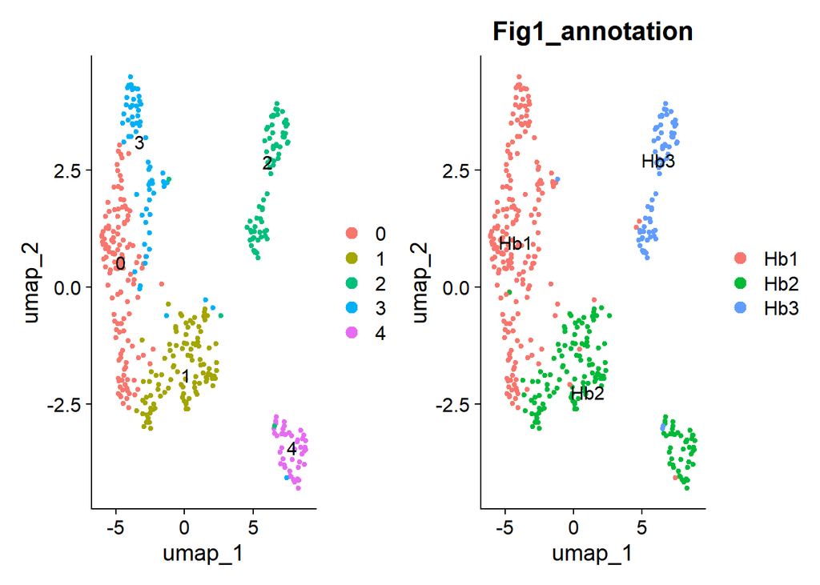

```r
Idents(object = HB_normalized_cells) <- "RNA_snn_res.0.4"
DimPlot(HB_normalized_cells, label = T) | DimPlot(HB_normalized_cells, label = T, group.by = "Fig1_annotation")
```

# 5. Annotation

- Prior to annotation we performed DEG analysis (not included in this script) to identify cluster-specific genes. Using these results together with knowledge from previously published data we assigned the cluster identities.
- After annotation we repeated DEG analysis (see section 7) to generate the marker gene table, provided in Supplementary Table 3 of the manuscript, with annotated cluster names.

## 5.1 CA markers

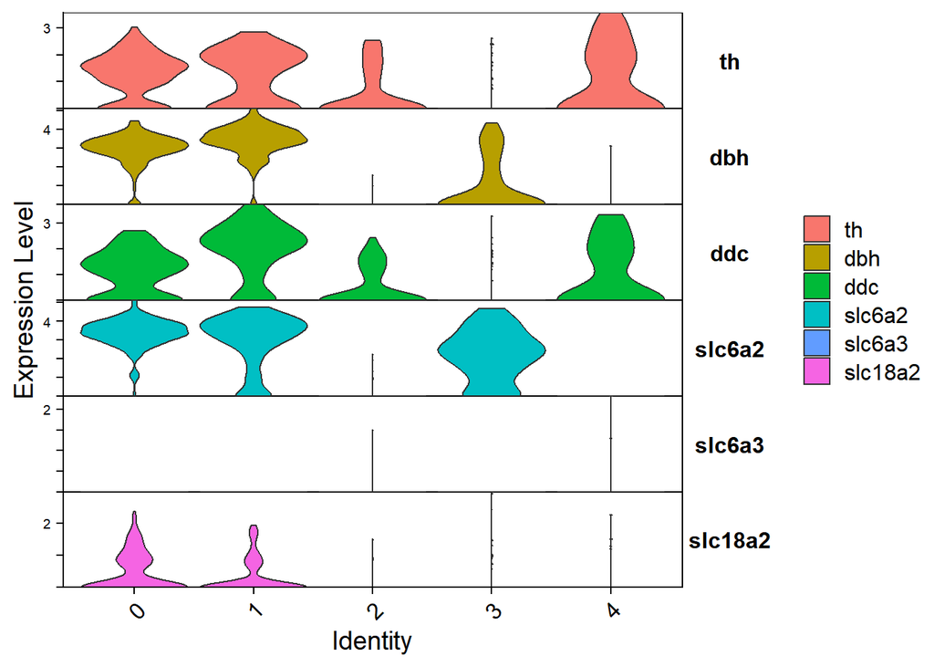

```r
DefaultAssay(HB_normalized_cells) <- "RNA"
VlnPlot(HB_normalized_cells, features = c("th", "dbh", "ddc", "slc6a2", "slc6a3", "slc18a2"), stack = T, flip = T)
```

## 5.2 MO1

- Cluster 0 shows enriched expression of the transcription factors sall3b, sox12, znf503
- We can also detect expression of tfap2a, lmx1bb as suggested for NA neurons in the hindbrain (Filippi et al., 2012; 10.1016/j.ydbio.2012.06.010; Holzschuh et al., 2003; 10.1242/dev.00816)
- As this cluster appears to be mainly glutamatergic (expression slc17a6a, slc17a6b, slc17a7a) we suggest it to be part of the medulla oblongata (MO) and not part of the GABAergic zebrafish locus coeruleus (LC) (Filippi et al., 2014; 10.1002/cne.23524) and annotated it as MO1
- We stained for nr4a3 and it appears to be expressed in several cells of the MO together with th. See figure 3 in the manuscript.
- Label: cl0 = MO1

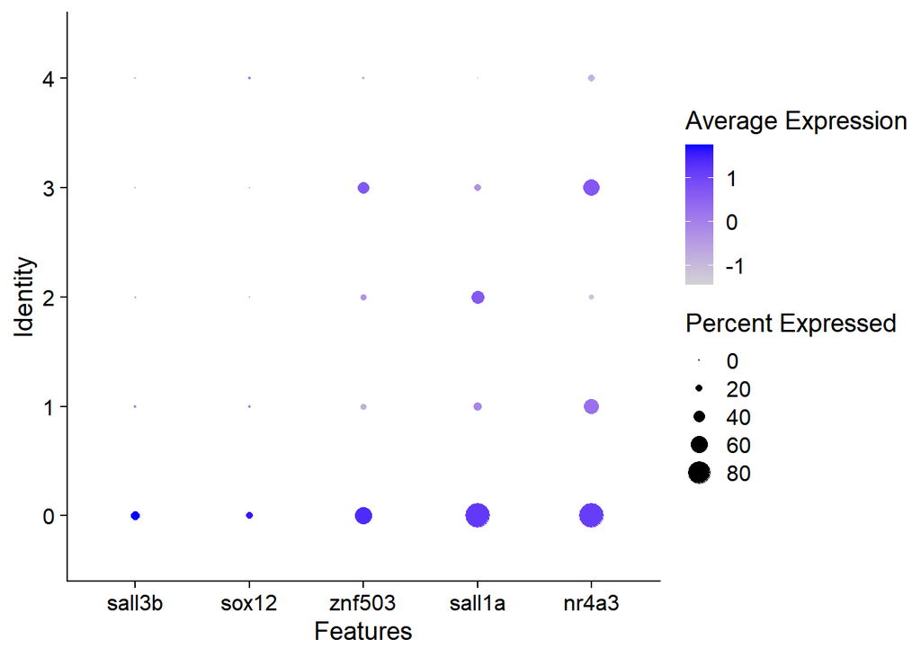

  ```r
  DotPlot(HB_normalized_cells, features = c("sall3b", "sox12", "znf503", "sall1a", "nr4a3"))
  ```

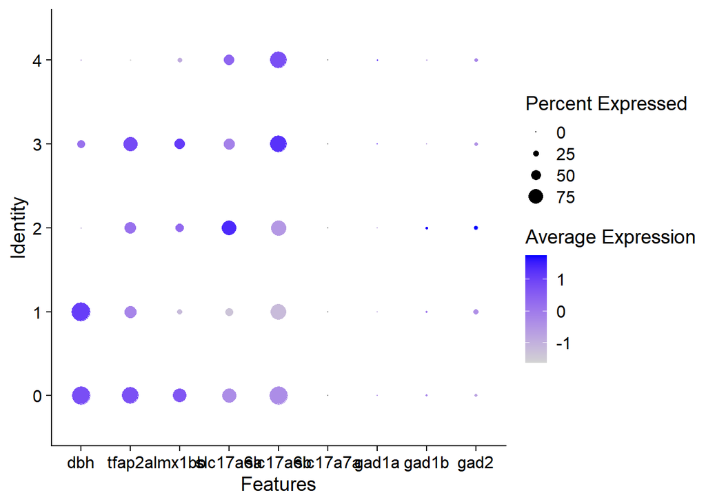

  ```r
  DotPlot(HB_normalized_cells, features = c("dbh", "tfap2a", "lmx1bb", "slc17a6a", "slc17a6b", "slc17a7a", "gad1a", "gad1b", "gad2"))
  ```

## 5.3 MO2

- Cluster 1 shows enriched expression of the transcription factors foxo1a, mef2cb, hlfb, roraa
- We can also detect expression of tfap2a, lmx1bb as suggested for NA neurons in the hindbrain (Filippi et al., 2012; 10.1016/j.ydbio.2012.06.010; Holzschuh et al., 2003; 10.1242/dev.00816)
- As this cluster appears to be mainly glutamatergic (expression slc17a6a, slc17a6b, slc17a7a) we suggest it to be part of the medulla oblongata (MO) and not part of the GABAergic zebrafish locus coeruleus (LC) (Filippi et al., 2014; 10.1002/cne.23524)
- Label: cl1= MO2

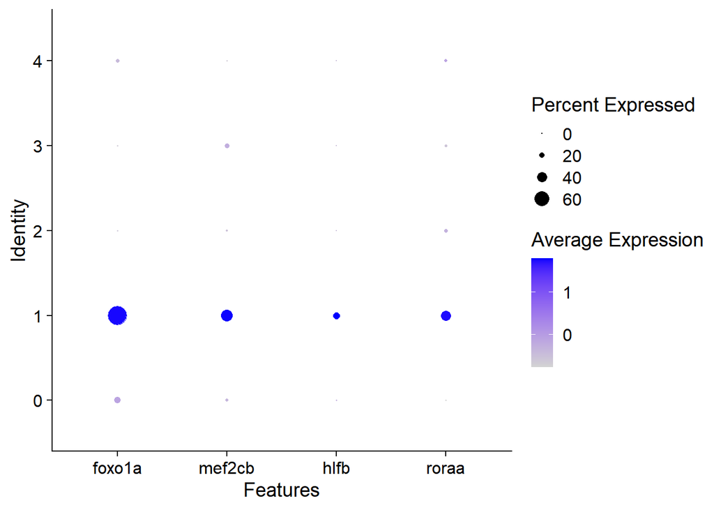

```r
DotPlot(HB_normalized_cells, features = c("foxo1a", "mef2cb","hlfb", "roraa"))
```

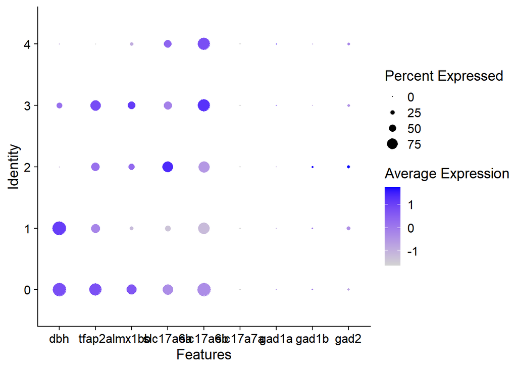

```r
DotPlot(HB_normalized_cells, features = c("dbh", "tfap2a", "lmx1bb", "slc17a6a", "slc17a6b", "slc17a7a", "gad1a", "gad1b", "gad2"))
```

## 5.4 dmMO

- Cluster 2 shows enriched expression of the transcription factors im:7142702, pou4f1, tlx3b, pou3f1
- We can detect expression of tfap2a, lmx1bb as suggested for NA neurons in the hindbrain (Filippi et al., 2012; 10.1016/j.ydbio.2012.06.010; Holzschuh et al., 2003; 10.1242/dev.00816)
- However, dbh and the noradrenergic reuptake transporter net (slc6a2) expression appears largely absent in this cluster suggesting that it might not produce NA.
- As this cluster appears to be mainly glutamatergic (expression slc17a6a, slc17a6b, slc17a7a) we suggest it to be part of the medulla oblongata (MO) and not part of the GABAergic zebrafish locus coeruleus (LC) (Filippi et al., 2014; 10.1002/cne.23524) .
- We stained for pou4f1 and it appears to be expressed specifically in the dorsomedial MO together with th. See figure 3 in the manuscript.
- Label: cl2 = dmMO

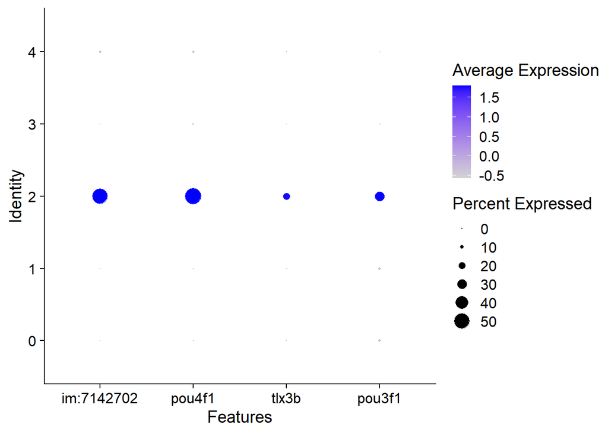

```r
DotPlot(HB_normalized_cells, features = c("im:7142702", "pou4f1", "tlx3b", "pou3f1"))
```

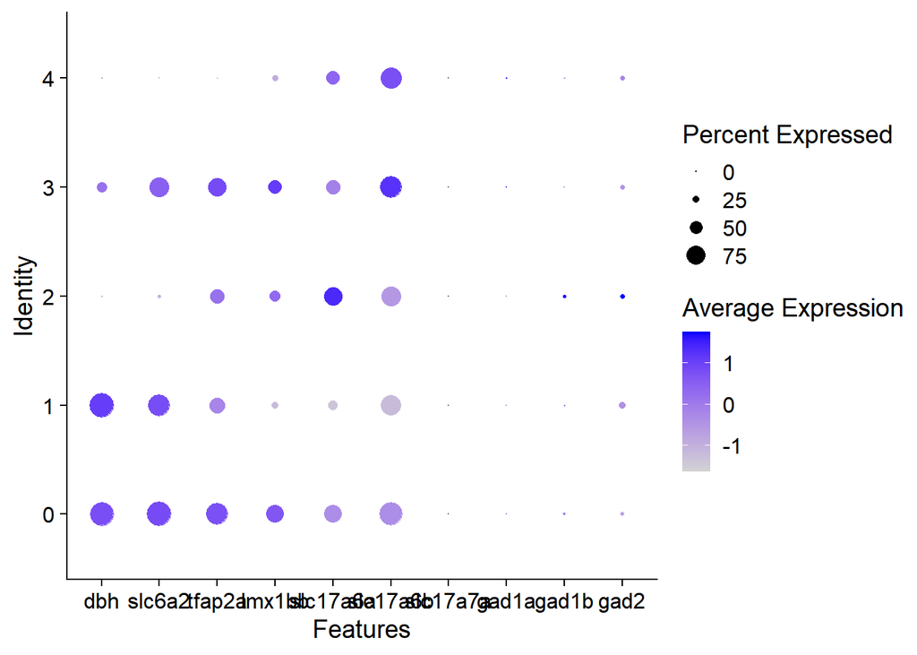

```r
DotPlot(HB_normalized_cells, features = c("dbh","slc6a2", "tfap2a", "lmx1bb", "slc17a6a", "slc17a6b", "slc17a7a", "gad1a", "gad1b", "gad2"))
```

## 5.6 AP

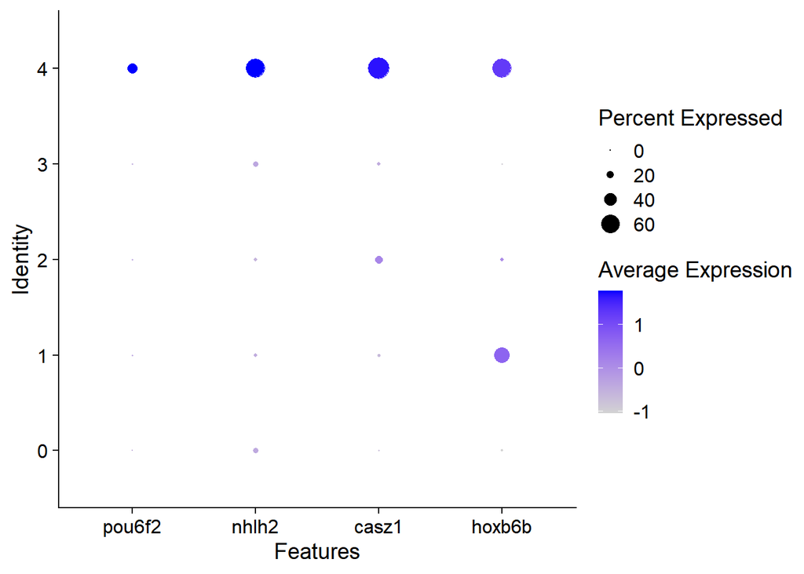

```r
DotPlot(HB_normalized_cells, features = c("pou6f2", "nhlh2", "casz1", "hoxb6b"))
```

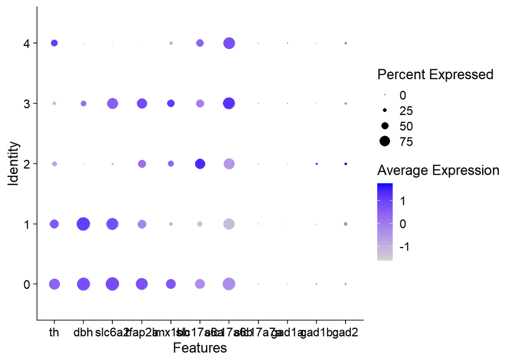

```r
DotPlot(HB_normalized_cells, features = c("th", "dbh","slc6a2", "tfap2a", "lmx1bb", "slc17a6a", "slc17a6b", "slc17a7a", "gad1a", "gad1b", "gad2"))
```

## 5.7 alMO

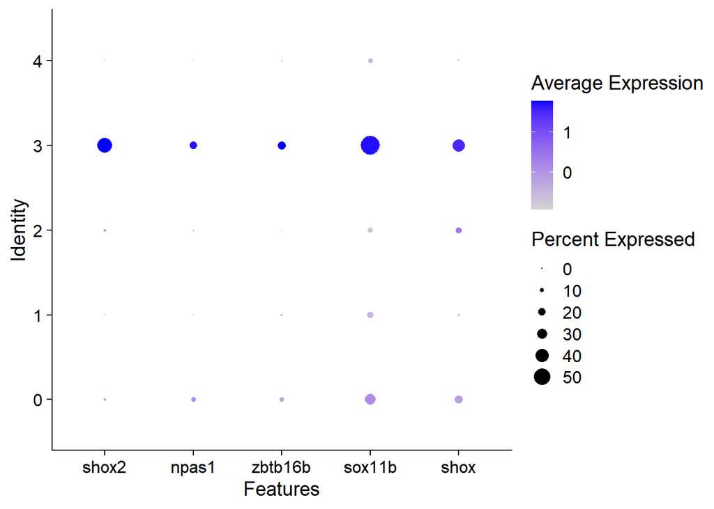

```r
DotPlot(HB_normalized_cells, features = c("shox2", "npas1", "zbtb16b", "sox11b", "shox"))
```

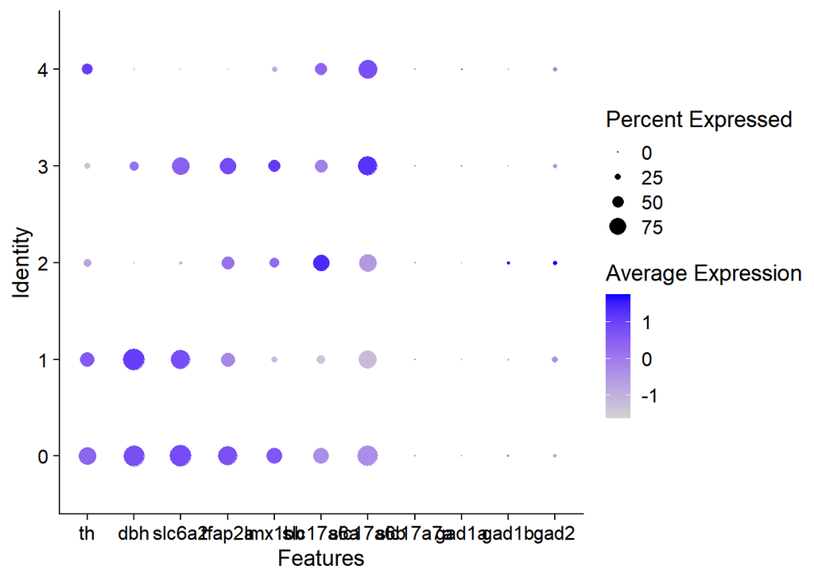

```r
DotPlot(HB_normalized_cells, features = c("th", "dbh","slc6a2", "tfap2a", "lmx1bb", "slc17a6a", "slc17a6b", "slc17a7a", "gad1a", "gad1b", "gad2"))
```

## 5.8 Annotation

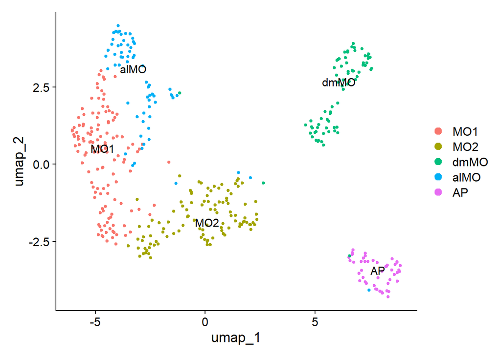

```r
HB_normalized_cells <- RenameIdents(object = HB_normalized_cells, "0" = "MO1", "1"= "MO2", "2" = "dmMO", "3" = "alMO", "4" = "AP")

HB_normalized_cells$Fig4_annotation <- HB_normalized_cells@active.ident

DimPlot(HB_normalized_cells, label = T)
```

# 6. Save Seurat object with annotations

```r
saveRDS(HB_normalized_cells, "RDS_files/Script9_Armbruster2026_Hindbrain.rds")


HB_normalized_cells <- read_rds("RDS_files/Script9_Armbruster2026_Hindbrain.rds")
```

# 7. DEG Analysis of annotated Seurat object

```r
###################################################################################
# Calculate DEGs and generate dataframes for all DEGs and TF DEGs
norm_markers <- FindAllMarkers(HB_normalized_cells, only.pos = TRUE, min.pct = 0.2, logfc.threshold = .25)
```

[output not shown]

```r
# Only include DEGs with adjusted p-value < 0.05
try(norm_markers <- dplyr::filter(norm_markers, p_val_adj <= 0.05))

# Sort by avg_log2FC
norm_markers_sorted <- norm_markers %>% group_by(cluster) %>% dplyr::arrange(desc(avg_log2FC), .by_group = T)


# Gene as first column
norm_markers_sorted <- norm_markers_sorted %>% relocate(gene, .before = p_val) %>% relocate(cluster, .before = gene)

# Sort for top 50 transcription factor DEGs and save as file
TFlist <- read_tsv(file = "Resources/DanioRerio_TF.tsv")
```

```r
TFlist$Species <- NULL
TFlist$Ensembl <- NULL
TFlist$Family <- NULL
TFlist$Protein <- NULL
TFlist$`Entrez ID` <- NULL
TFlist <- TFlist[!duplicated(TFlist), ]

names(TFlist)[names(TFlist) == "Symbol"] <- "gene"

TF_markers <- inner_join(norm_markers, TFlist, by = "gene")

# Sort by avg_log2FC
TF_markers_sorted <- TF_markers %>% group_by(cluster) %>% dplyr::arrange(desc(avg_log2FC), .by_group = T)
TF_markers_sorted <- TF_markers_sorted %>% relocate(gene, .before = p_val) %>% relocate(cluster, .before = gene)

###################################################################################
# Get count info about the DEGs for all clusters

# ALL GENES:
#Get sum of norm counts within cluster
norm_markers_sumcounts_per_cluster <- AggregateExpression(
  HB_normalized_cells,
  assays   = "RNA",
  slot     = "data",
  features = norm_markers$gene,
  group.by = "Fig4_annotation",
  verbose  = FALSE
)
# Get avg of norm counts within cluster
norm_markers_avgcounts_per_cluster <- AverageExpression(
  HB_normalized_cells,
  assays   = "RNA",
  slot     = "data",
  features = norm_markers$gene,
  group.by = "Fig4_annotation",
  verbose  = FALSE
)
```

```
## As of Seurat v5, we recommend using AggregateExpression to perform pseudo-bulk analysis.
```

```r
# Generate combined df for the count
norm_markers_sumcounts_per_cluster <- as.data.frame(norm_markers_sumcounts_per_cluster)
colnames(norm_markers_sumcounts_per_cluster) <- paste(colnames(norm_markers_sumcounts_per_cluster), "_sum_normcount", sep="")
norm_markers_avgcounts_per_cluster <- as.data.frame(norm_markers_avgcounts_per_cluster)
colnames(norm_markers_avgcounts_per_cluster) <- paste(colnames(norm_markers_avgcounts_per_cluster), "_avg_normcount", sep="")
norm_markers_counts_per_cluster <- cbind(norm_markers_sumcounts_per_cluster, norm_markers_avgcounts_per_cluster)
norm_markers_counts_per_cluster <- norm_markers_counts_per_cluster[, order(colnames(norm_markers_counts_per_cluster))]

# TRANSCRIPTION FACTORS:
#Get sum of normcounts within cluster
TF_markers_sumcounts_per_cluster <- AggregateExpression(
  HB_normalized_cells,
  assays   = "RNA",
  slot     = "data",
  features = TF_markers$gene,
  group.by = "Fig4_annotation",
  verbose  = FALSE
)
# Get avg of normcounts within cluster
TF_markers_avgcounts_per_cluster <- AverageExpression(
  HB_normalized_cells,
  assays   = "RNA",
  slot     = "data",
  features = TF_markers$gene,
  group.by = "Fig4_annotation",
  verbose  = FALSE
)

# Generate combined df for the count
TF_markers_sumcounts_per_cluster <- as.data.frame(TF_markers_sumcounts_per_cluster)
colnames(TF_markers_sumcounts_per_cluster) <- paste(colnames(TF_markers_sumcounts_per_cluster), "_sum_normcount", sep="")
TF_markers_avgcounts_per_cluster <- as.data.frame(TF_markers_avgcounts_per_cluster)
colnames(TF_markers_avgcounts_per_cluster) <- paste(colnames(TF_markers_avgcounts_per_cluster), "_avg_normcount", sep="")
TF_markers_counts_per_cluster <- cbind(TF_markers_sumcounts_per_cluster, TF_markers_avgcounts_per_cluster)
TF_markers_counts_per_cluster <- TF_markers_counts_per_cluster[, order(colnames(TF_markers_counts_per_cluster))]

##########################################################################
# Cell number per cluster
n_cells <- FetchData(HB_normalized_cells,
                     vars = c("ident", "orig.ident")) %>% dplyr::count(ident, orig.ident) %>% tidyr::spread(ident,n)

n_cells <- as.data.frame(t(n_cells))
n_cells<- n_cells %>% dplyr::filter(row_number() != 1)
n_cells
```

```
##       V1
## MO1  130
## MO2  107
## dmMO  74
## alMO  65
## AP    47
```

```r
colnames(n_cells) <- "CellNumber"
n_cells$CellNumber <- as.numeric(n_cells$CellNumber)

n_cells
```

```
##      CellNumber
## MO1         130
## MO2         107
## dmMO         74
## alMO         65
## AP           47
```

```r
# Generate xlsx files
dataframe_names <- list("CellNumbers" = n_cells, "All_DEGs" = norm_markers_sorted, "TF_DEGs" = TF_markers_sorted, "All_DEGs_CountInformation" = norm_markers_counts_per_cluster, "TF_DEGs_CountInformation" = TF_markers_counts_per_cluster)



openxlsx::write.xlsx(dataframe_names, file = "DEG_tables/Script9_Hindbrain/Script9_Hindbrain_DEG_Info.xlsx", rowNames=T)
```

# 8. For Figure 3 + Figure S3

## 8.1 UMAP with cluster annotation

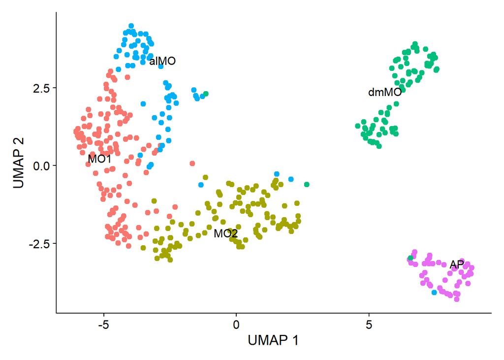

```r
HBNA_DimPlot <- DimPlot(HB_normalized_cells, pt.size = 2, label = T, repel = T) +
  NoLegend() +
  labs(x = "UMAP 1", y = "UMAP 2") +
    theme(
        plot.title = element_text(size = 16, face = "bold")
    )

print(HBNA_DimPlot)
```

```r
ggsave("Script9_Fig4_HBNA_DimPlot.svg", plot = HBNA_DimPlot, path = "Figures/Figure3_Hindbrain/", width = 5, height = 4)
```

## 8.2 FeaturePlots for relevant genes

```
## [1] "dbh"
```

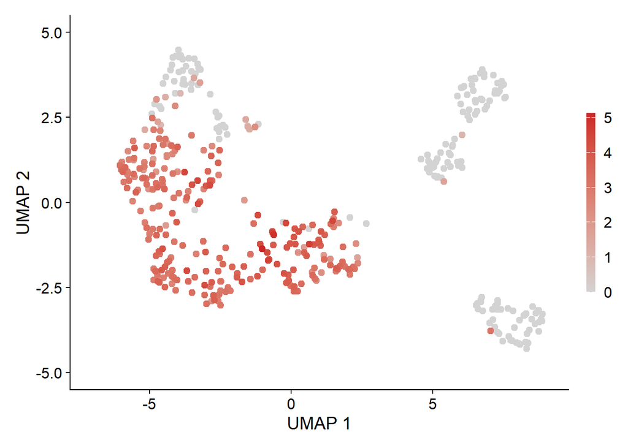

```
## [1] "th"
```

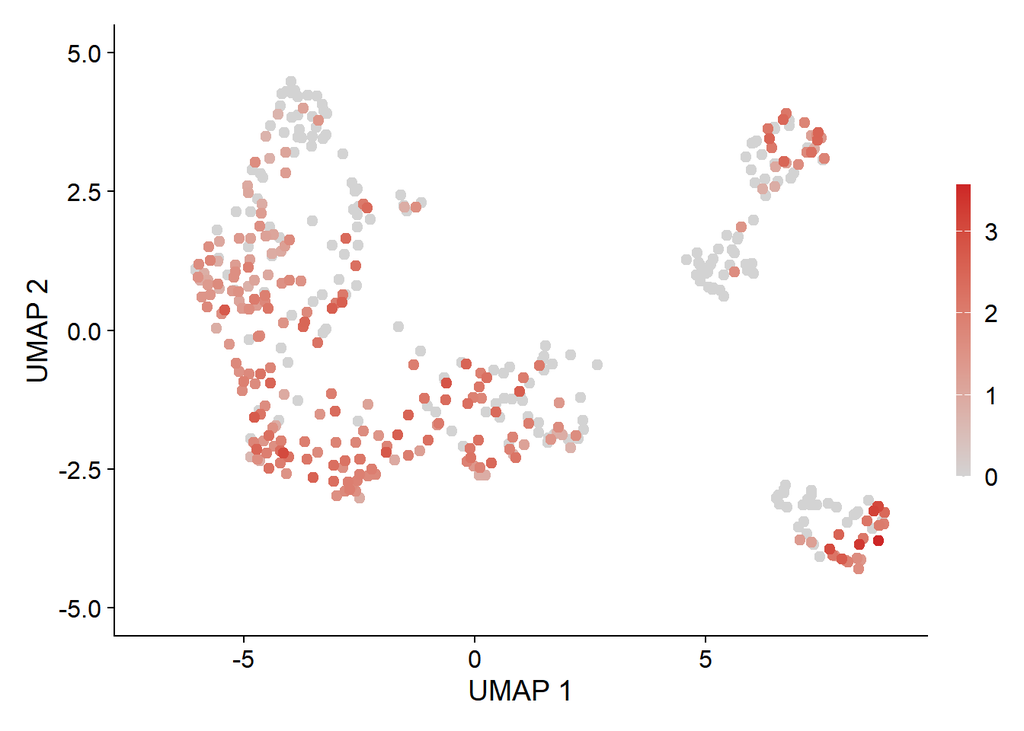

```
## [1] "nr4a3"
```

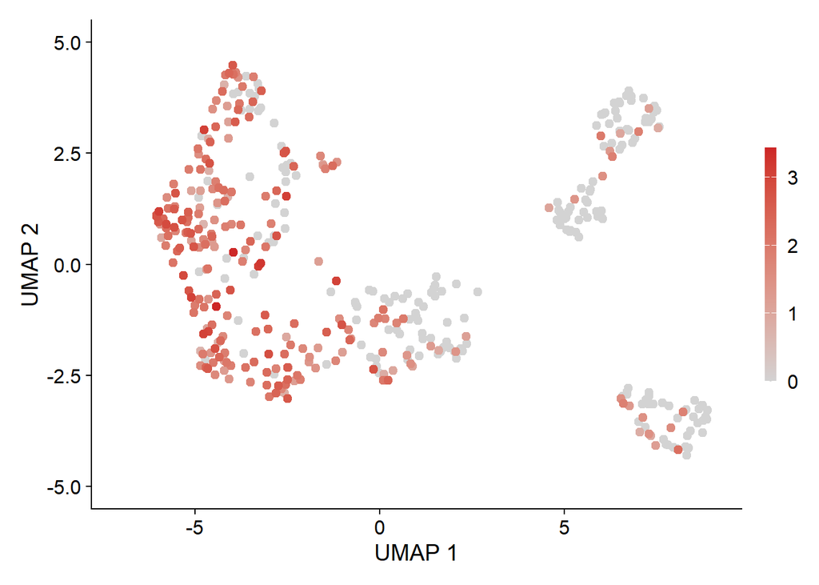

```
## [1] "shox2"
```

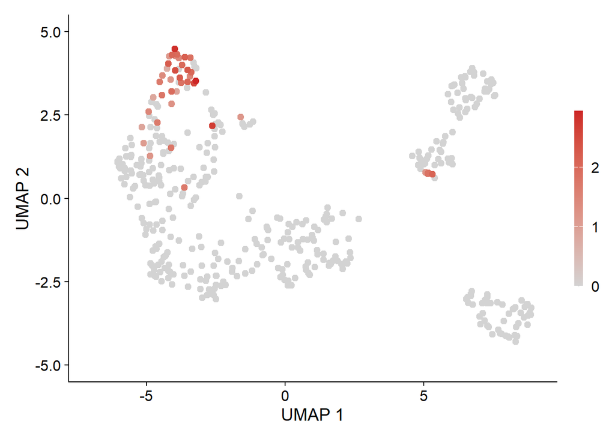

```
## [1] "pou4f1"
```

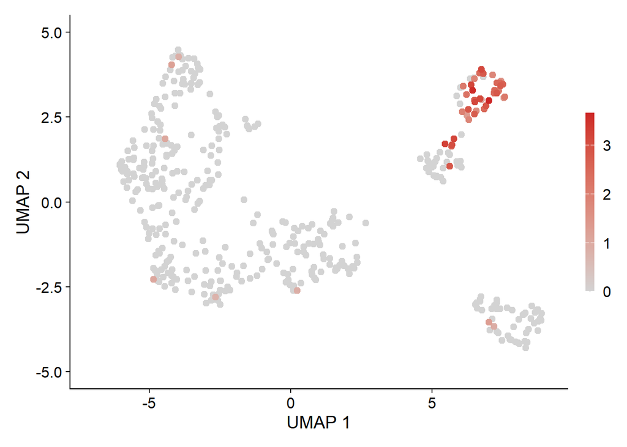

```
## [1] "hoxb6b"
```

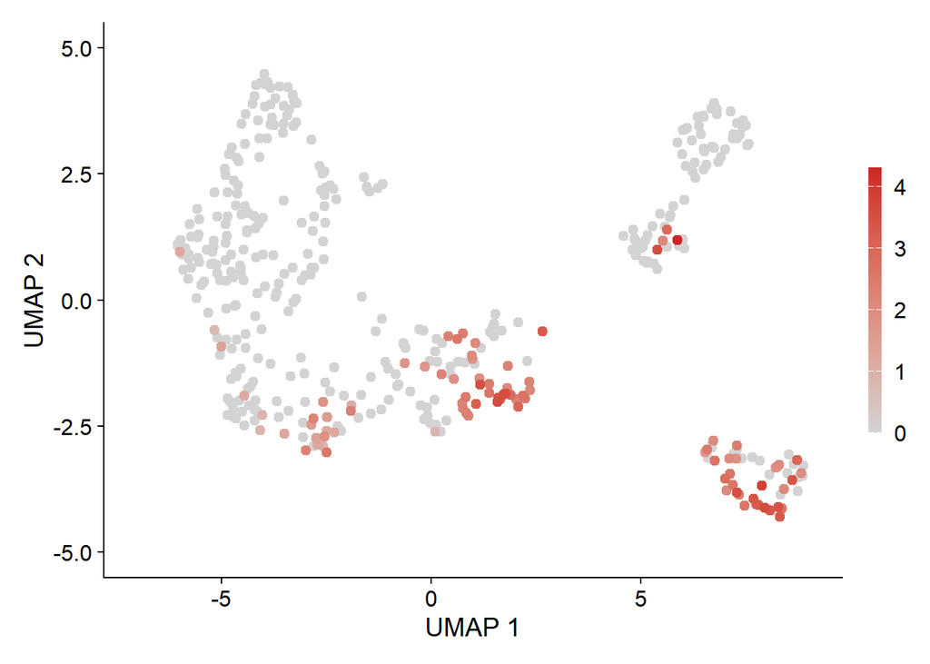

```
## [1] "slc6a3"
```

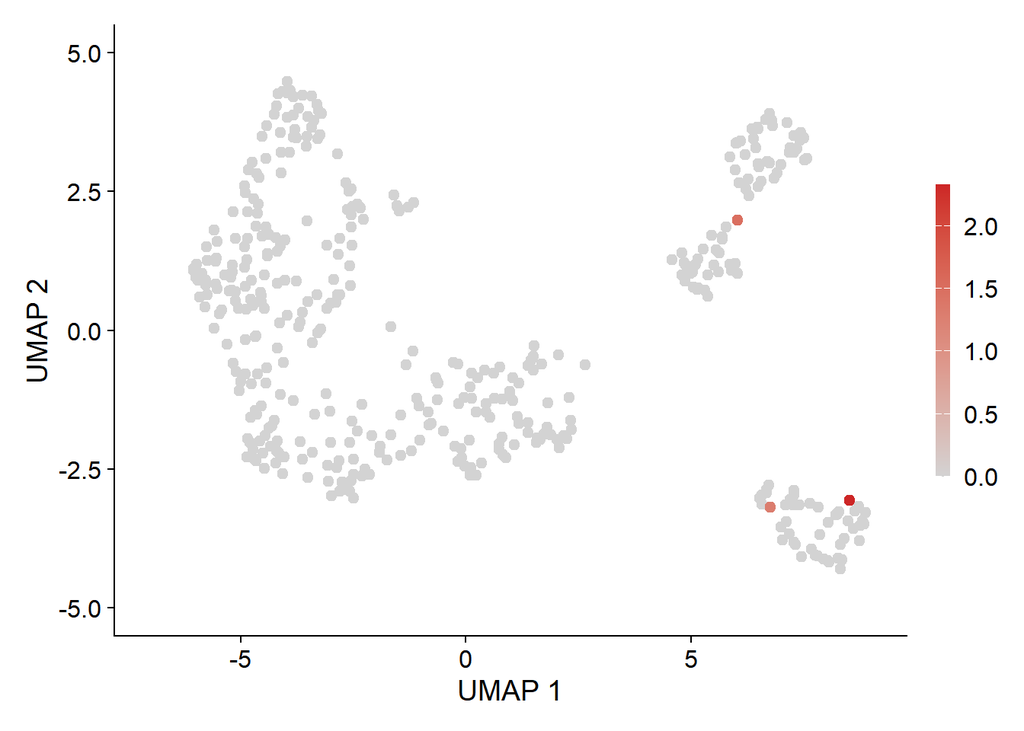

```
## [1] "ddc"
```

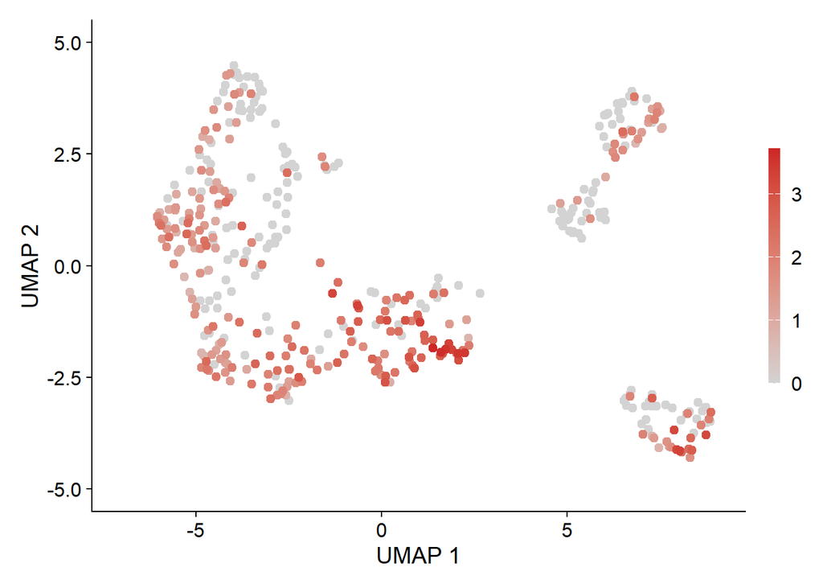

```
## [1] "slc6a2"
```

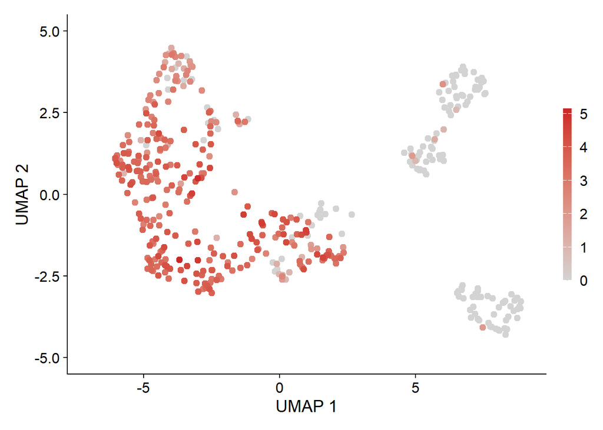

```
## [1] "slc18a2"
```

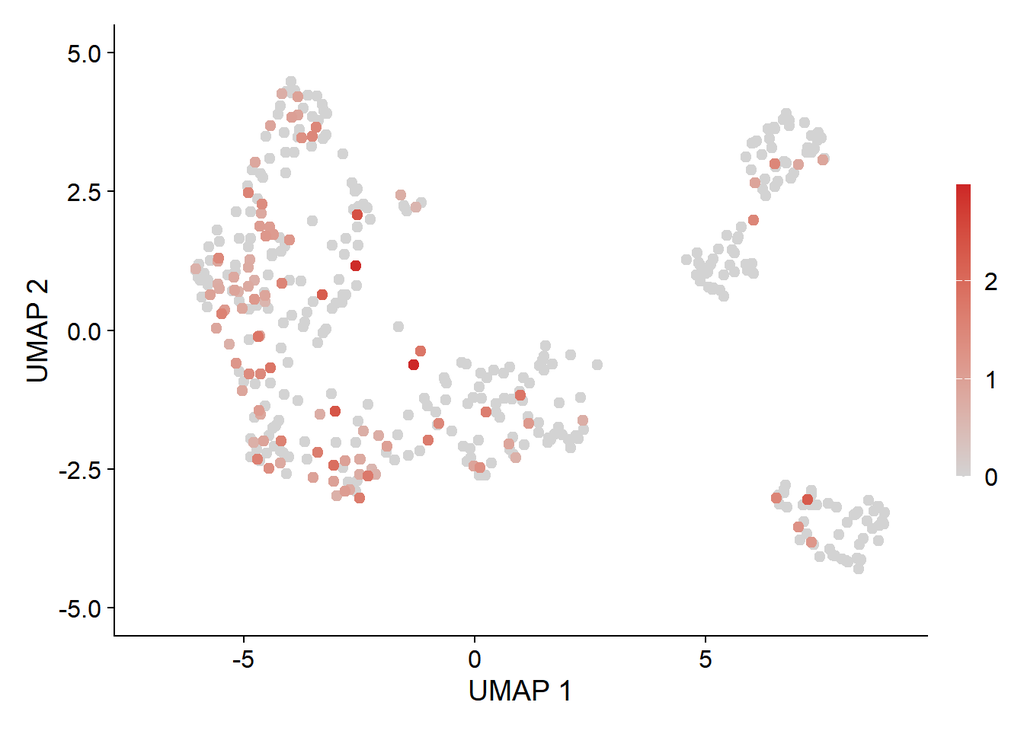

```r
genes <- c("dbh", "th", "nr4a3", "shox2", "pou4f1", "hoxb6b", "slc6a3", "ddc", "slc6a2" , "slc18a2")

for (gene in genes) {
  plot <- FeaturePlot(HB_normalized_cells, gene, pt.size = 2, order = T) +
    scale_colour_gradient(low="lightgrey", high="#cd2626") +
    labs(x = "UMAP 1", y = "UMAP 2", title = NULL) +
    guides(color = guide_colorbar(barwidth = 0.5, barheight = 10))
    plot_name <- paste("Script9_Fig4_FeaturePlots_", gene,".svg", sep = "")
    print(gene)
    print(plot)
    ggsave(plot_name, plot = plot, path = "Figures/Figure3_Hindbrain/",
           width = 5, height = 4)

}
```

## 8.3 *hox RC score plot*

- As approximation for the position of hindbrain cells, a *hox* gene expressionrostro-caudal identity score (*hox* RC score) was calculated under the assumption that lower numbered *hox* paralog groups (e.g. *hoxa1a*, *hoxb2a*) are in general expressed more rostrally whereas higher numbered paralog groups (e.g. *hoxa6a*, *hoxb8b*) are expressed progressively more caudally (Lumsden & Krumlauf, 1996). The *hox* gene expression values from the Seurat object of hindbrain CA neurons were used to calculate a weighted mean of the *hox* paralog numbers for each cell as follows: the summed-up products of the *hox* gene expression values and the paralog group number of each gene were divided by the total *hox* gene expression counts of that cell and used as proxy for the corresponding positional values. This score was saved to the metadata of the Seurat object for visualization.

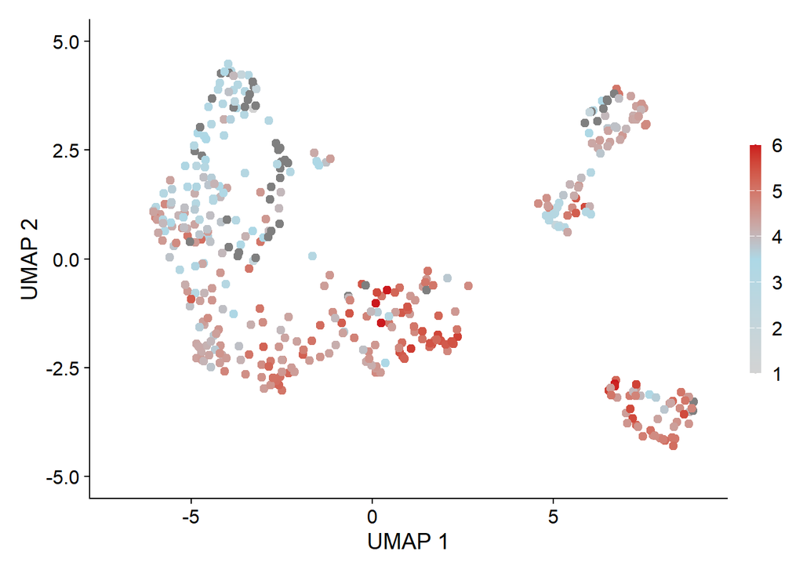

```r
# Hox genes of zebrafish
zf_hox_names <- c("hoxa1a", "hoxb1a", "hoxb1b","hoxc1a", "hoxa2b", "hoxb2a", "hoxb3a", "hoxc3a","hoxd3a", "hoxa4a","hoxb4a", "hoxc4a", "hoxd4a", "hoxa5a", "hoxb5a", "hoxb5b","hoxc5a", "hoxb6a", "hoxb6b","hoxc6a", "hoxc6b", "hoxb7a", "hoxb8a","hoxb8b","hoxc8a", "hoxa9a", "hoxb9a","hoxa9b", "hoxc9a", "hoxd9a", "hoxa10b", "hoxb10a","hoxc10a", "hoxd10a", "hoxa11a",  "hoxa11b","hoxc11a",  "hoxc11b", "hoxd11a", "hoxc12a","hoxc12b","hoxd12a", "hoxa13a", "hoxa13b", "hoxb13a" , "hoxc13a", "hoxc13b", "hoxd13a")

# Corresponding ortholog group number (e.g. hoxa1a = 1, hoxa2a = 2...)
zf_hox_numbers <- c(1,1,1,1,2,2,3,3,3,4,4,4,4,5,5,5,5,6,6,6,6,7,8,8,8,9,9,9,9,9,10,10,10,10,11,11,11,11,11,12,12,12,13,13,13,13,13,13)

# Generate dataframe for hox genes and the respective group numbers
zf_hox_df <- data.frame("gene" = zf_hox_names, "number" = zf_hox_numbers)

# Filter for hox genes that are present in the dataset
zf_hox_in_dataset <- intersect(zf_hox_df$gene, rownames(HB_normalized_cells))

# Number of hox genes in dataset
hoxgene_count <- length(zf_hox_in_dataset)

# Extract dataframe of expression of hox genes in dataset
hox_expression <- FetchData(HB_normalized_cells, vars = zf_hox_in_dataset)

# Only include hox gene numbers of hox genes expressed in the dataset
hox_numbers <- zf_hox_df$number[match(zf_hox_in_dataset, zf_hox_df$gene)]


# Function that calculated the weighted mean hox RC score for each cell

calculate_hox_score <- function(cell_expr, hox_numbers) {
  # Keep only non-zero expression genes for the cell
  non_zero_expr <- cell_expr[cell_expr > 0]

  # Use hox gene number as proxy for the rostro-caudal position
  positions <- hox_numbers[match(names(non_zero_expr), zf_hox_in_dataset)]

  # Calculate the weighted average (sum(weighted expression) / sum(expression))
  score <- sum(non_zero_expr * positions) / sum(non_zero_expr)

  return(score)
}

# Calculate hox score for the cells
hox_scores <- apply(hox_expression, 1, function(x) calculate_hox_score(x, hox_numbers))


# Assign hox score to metadata of Seurat object
HB_normalized_cells$Hox_Score <- hox_scores


FeaturePlot_HoxScore <- FeaturePlot(HB_normalized_cells, "Hox_Score", pt.size = 2, max.cutoff = 6) +  scale_color_gradientn( colours = c("lightgrey", "lightblue", "#cb181d")) + labs(x = "UMAP 1", y = "UMAP 2", title = NULL) + guides(color = guide_colorbar(barwidth = 0.5, barheight = 10))
print(FeaturePlot_HoxScore)
```

```r
ggsave("Script9_Fig4_HB_HoxScore.svg", plot = FeaturePlot_HoxScore, path = "Figures/Figure3_Hindbrain/", width = 5, height = 4)
```

## 8.4 *hox* Gene Dotplot

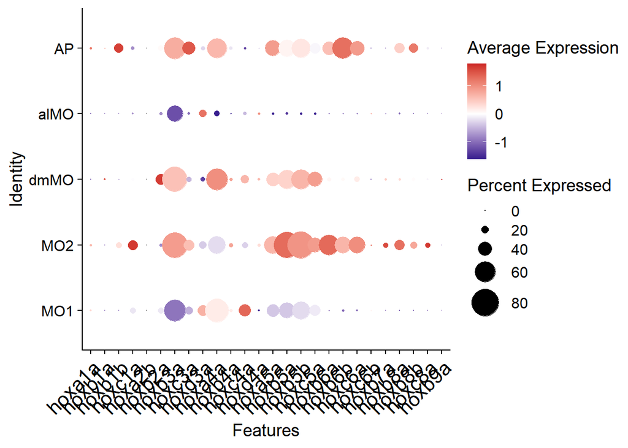

```r
Fig4_HoxDotplot <- DotPlot(HB_normalized_cells, features = zf_hox_names, dot.scale = 10, scale.max = 80) +
  scale_color_gradient2(low="navy", mid="white", high="firebrick3") +
  theme(axis.text.x = element_text(angle = 45, hjust = 1, size = 16))
print(Fig4_HoxDotplot)
```

```r
ggsave("Script9_Fig4_HoxDotplot.svg", plot = Fig4_HoxDotplot, path = "Figures/Figure3_Hindbrain/", width = 16, height = 3)
```

## 8.5 Heatmap (cluster-level)

```r
# Get top50 TFs per cluster from the DEG file
TF_markers_merge_seurat_Top50 <- TF_markers_sorted %>% group_by(cluster) %>% top_n(n = 50, wt = avg_log2FC) %>% dplyr::arrange(desc(avg_log2FC), .by_group = T)

TF_markers_merge_seurat_Top50
```

```
## # A tibble: 80 × 7
## # Groups:   cluster [5]
##    cluster gene      p_val avg_log2FC pct.1 pct.2 p_val_adj
##    <fct>   <chr>     <dbl>      <dbl> <dbl> <dbl>     <dbl>
##  1 MO1     sall3b 2.53e-15       3.55 0.277 0.024  5.07e-11
##  2 MO1     sox12  3.31e- 8       2.50 0.2   0.038  6.62e- 4
##  3 MO1     znf503 3.42e-17       1.83 0.608 0.205  6.85e-13
##  4 MO1     sall1a 2.58e-30       1.68 0.877 0.253  5.16e-26
##  5 MO1     meis3  2.59e-14       1.63 0.523 0.164  5.18e-10
##  6 MO1     pbx1a  9.86e-23       1.49 0.877 0.386  1.97e-18
##  7 MO1     nr4a3  1.16e-21       1.48 0.885 0.389  2.33e-17
##  8 MO1     hoxc4a 1.26e- 6       1.47 0.338 0.14   2.52e- 2
##  9 MO1     zbtb2b 4.56e- 7       1.42 0.246 0.068  9.13e- 3
## 10 MO1     egr4   1.88e-14       1.38 0.838 0.543  3.76e-10
## # ℹ 70 more rows
```

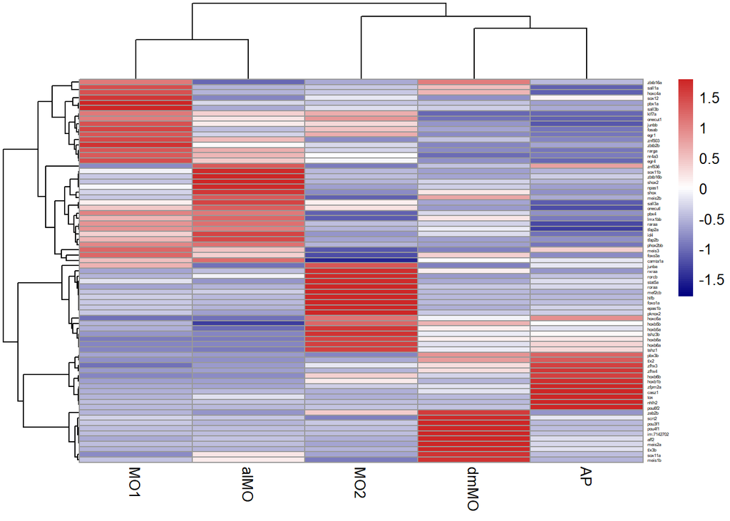

```r
# Calculate avg. normalized expression for each of these TFs, scale them and visualize in heatmap.
avg <- AverageExpression(
  HB_normalized_cells,
  features = TF_markers_sorted$gene,
  group.by = "ident",
  assays = DefaultAssay(HB_normalized_cells),
  slot = "data"
)
avg_mat <- avg[[DefaultAssay(HB_normalized_cells)]]
avg_scaled <- t(scale(t(avg_mat)))
avg_scaled[is.na(avg_scaled)] <- 0

lim <- max(abs(avg_scaled))

breaks <- seq(-lim, lim, length.out = 101)


DEG_heatmap <- pheatmap::pheatmap(avg_scaled,
  cluster_rows = TRUE,
  cluster_cols = TRUE,
  clustering_distance_rows = "correlation",
  clustering_distance_cols = "correlation",
  clustering_method = "average",
  color = colorRampPalette(c("navy","white","firebrick3"))(100),
  breaks = breaks,
  silent = TRUE,
  width = 10,
  height = 10,
  fontsize_row = 3
)

print(DEG_heatmap)
```

```r
svg("DEG_tables/Script9_Hindbrain/Fig4_HB_Cluster_Heatmap.svg", width = 10, height = 10)
grid::grid.draw(DEG_heatmap$gtable)
dev.off()
```

```r
# Save data from heatmap

# Generate xlsx files with expression values the heatmap is based on
avg_mat <- as.data.frame(avg_mat)
avg_scaled <- as.data.frame(avg_scaled)

dataframe_names <- list("avg_normcounts" = avg_mat, "scaled_avg_normcounts" = avg_scaled)


openxlsx::write.xlsx(dataframe_names, file = "DEG_tables/Script9_Hindbrain/Script9_Hindbrain_HeatmapTable.xlsx", rowNames=T)
```

```r
# Define the top 3 most specific genes for a cluster which will be labelled in the heatmap
label_genes <- lapply(colnames(avg_scaled), function(cl){

  genes <- rownames(avg_scaled)[
    apply(avg_scaled, 1, which.max) == which(colnames(avg_scaled)==cl)
  ]

  zvals <- avg_scaled[genes, cl]

  head(genes[order(zvals, decreasing=TRUE)], 3)

})

label_genes <- unique(unlist(label_genes))
label_genes
```

```
##  [1] "pbx1a"      "sall3b"     "zbtb2b"     "foxo1a"     "hlfb"
##  [6] "mef2cb"     "pou4f1"     "im:7142702" "pou3f1"     "shox2"
## [11] "zbtb16b"    "sox11b"     "nhlh2"      "pou6f2"     "tox"
```

## 8.6 DotPlot CA markers

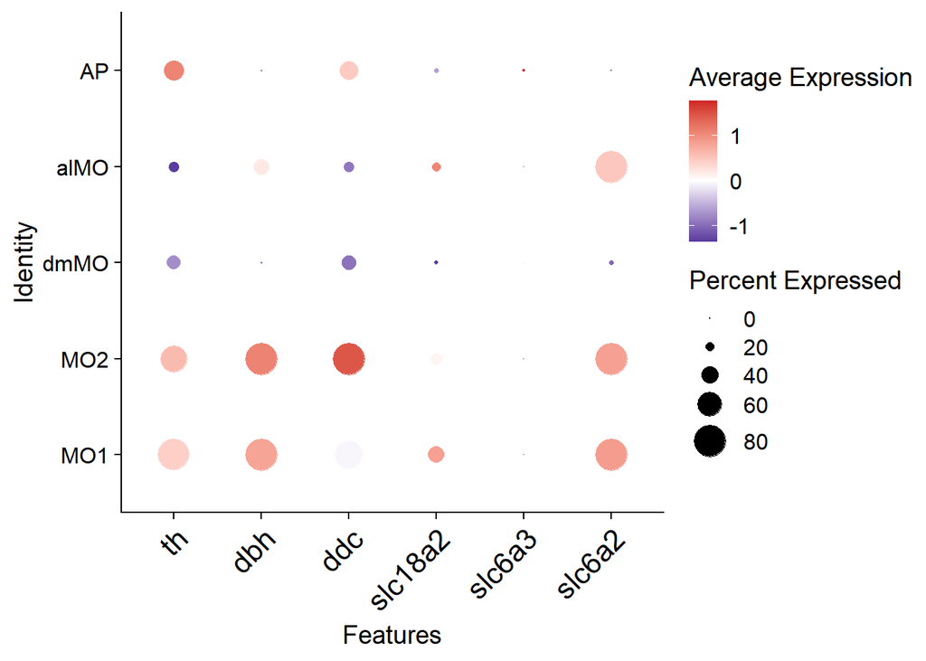

```r
CA_genes <- c("th", "dbh", "ddc", "slc18a2", "slc6a3", "slc6a2")
Fig4_CADotplot <- DotPlot(HB_normalized_cells, features = CA_genes, dot.scale = 8, scale.max = 80) +
  scale_color_gradient2(low="navyblue", mid = "white", high="#cd2626") +
  theme(axis.text.x = element_text(angle = 45, hjust = 1, size = 16))
print(Fig4_CADotplot)
```

```r
ggsave("Script9_Fig4_CADotplot.svg", plot = Fig4_CADotplot, path = "Figures/Figure3_Hindbrain/", width =5, height = 3)
```

```r
rm(list=ls())
gc()
```

```
##            used  (Mb) gc trigger  (Mb) max used  (Mb)
## Ncells  4169180 222.7    6545614 349.6  6545614 349.6
## Vcells 14099291 107.6   62859892 479.6 78574865 599.5
```